# ARIMA modeling

## 13.6 Slightly more complicated simulated ARIMA

250 observations from the ARIMA(2,1,0) model with drift given by

$$Y_t=1+1.5Y_{t−1}−.75Y_{t−2}+W_t$$

where $Y_t=\nabla X_t=X_t−X_{t−1}$

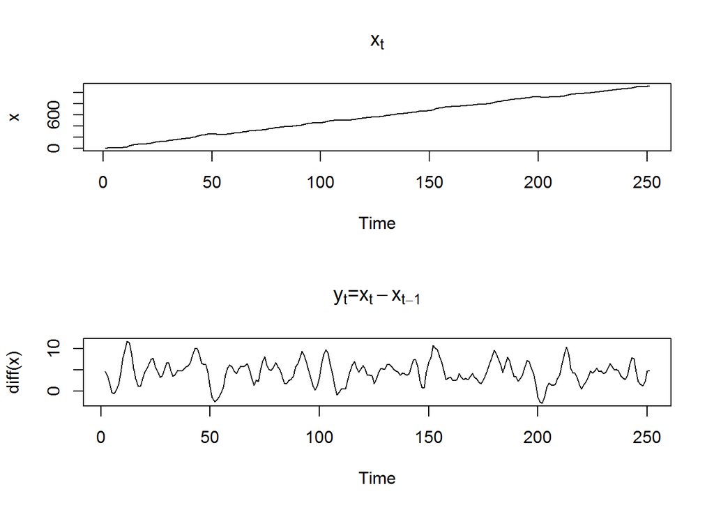

```r
x <- arima.sim(model = list(order = c(2, 1, 0), ar = c(1.5, -.75)), n = 250, mean=1)
par(mfrow=2:1)
plot(x, main=expression(x[t]))
plot(diff(x), main=expression(paste(y[t], "=", x[t]-x[t-1])))
```

Plot sample P/ACF of differenced data and determine model

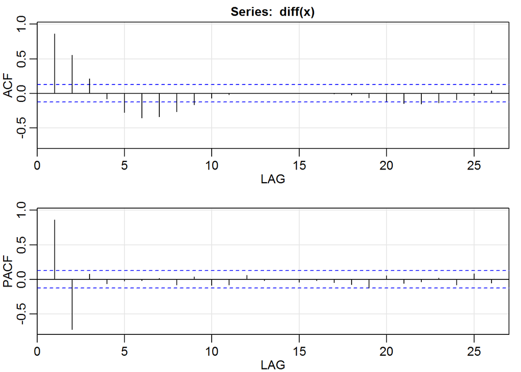

```r
invisible(acf2(diff(x)))
```

Estimate parameters and examine output

```r
sarima(x, 2,1,0, details=FALSE)$ttable
```

```
         Estimate     SE  t.value p.value
ar1        1.4775 0.0434  34.0389       0
ar2       -0.7172 0.0433 -16.5625       0
constant   4.4796 0.2535  17.6730       0
```

The estimated parameters are very close to 1.5 and -0.75

## 13.7 Global Warming

```r
plot(cbind(globtemp, diff(globtemp)), main="Global mean land-ocean temperature deviations")
```

[output not shown]

Plot the sample P/ACF pair of the differenced data

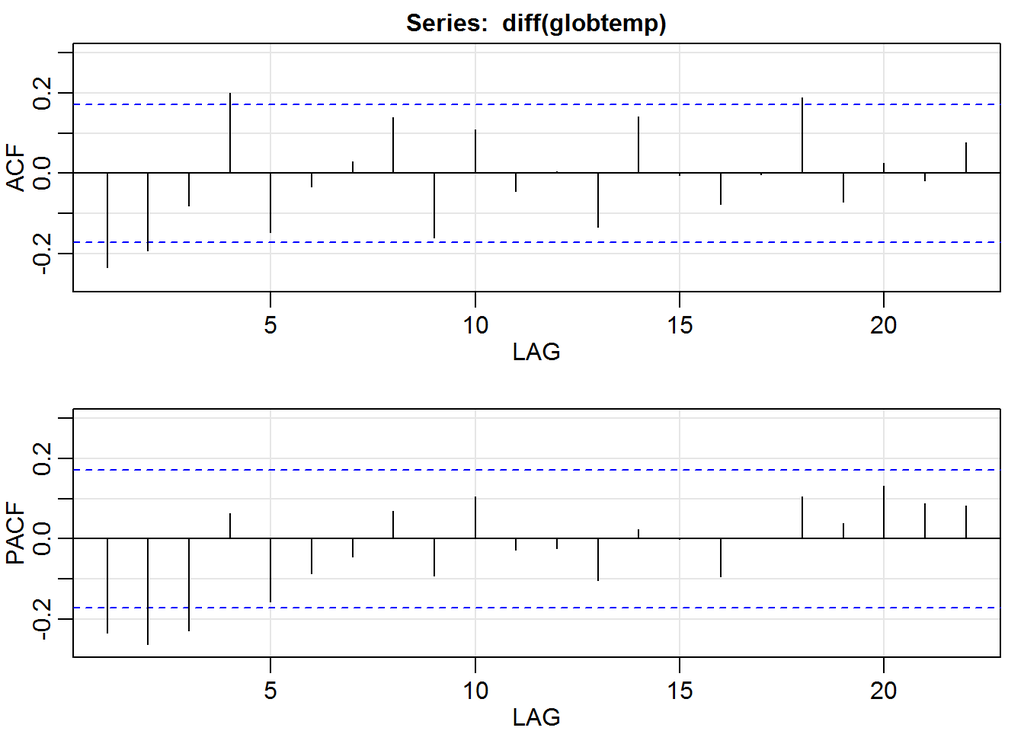

```r
invisible(acf2(diff(globtemp)))
```

Either:

1. The ACF and the PACF are both tailing off, implying an ARIMA(1,1,1) model.
2. The ACF cuts off at lag 2, and the PACF is tailing off, implying an ARIMA(0,1,2) model.
3. The ACF is tailing off and the PACF cuts off at lag 3, implying an ARIMA(3,1,0) model. Although this model fits reasonably well, it is the worst of the three (you can check it) because it uses too many parameters for such small autocorrelations.

Fit an ARIMA(1,1,1) model to globtemp

```r
sarima(globtemp, 1,1,1, details = FALSE)[c("ttable", "AIC", "BIC")]
```

```
$ttable
         Estimate     SE t.value p.value
ar1        0.3549 0.1314  2.7008  0.0078
ma1       -0.7663 0.0874 -8.7701  0.0000
constant   0.0072 0.0032  2.2738  0.0246

$AIC
[1] -3.572642

$BIC
[1] -4.508392
```

All parameters are significant.

Fit an ARIMA(0,1,2) model to globtemp

```r
sarima(globtemp, 0,1,2, details = FALSE)[c("ttable", "AIC", "BIC")]
```

```
$ttable
         Estimate     SE t.value p.value
ma1       -0.3984 0.0808 -4.9313  0.0000
ma2       -0.2173 0.0768 -2.8303  0.0054
constant   0.0072 0.0033  2.1463  0.0337

$AIC
[1] -3.579224

$BIC
[1] -4.514974
```

All parameters are significant and both AIC and BIC shows this model is a better fit.

Fit an ARIMA(3,1,0) model to globtemp

```r
sarima(globtemp, 3,1,0, details = FALSE)[c("ttable", "AIC", "BIC")]
```

```
$ttable
         Estimate     SE t.value p.value
ar1       -0.3669 0.0842 -4.3592  0.0000
ar2       -0.3421 0.0849 -4.0319  0.0001
ar3       -0.2363 0.0838 -2.8186  0.0056
constant   0.0071 0.0044  1.6168  0.1083

$AIC
[1] -3.573377

$BIC
[1] -4.487711
```

# 14 ARIMA Diagnostics

Diagnostics ARIMA models is the same as for ARMA models.

Once a model seems reasonable, try adding a parameter to see if it makes an improvement. If it does so, change the model, otherwise the model is fitted.

## 14.1 Weekly Oil Prices ARIMA(1,1,1)?

For this example, the Oil Series is subset until 2006.

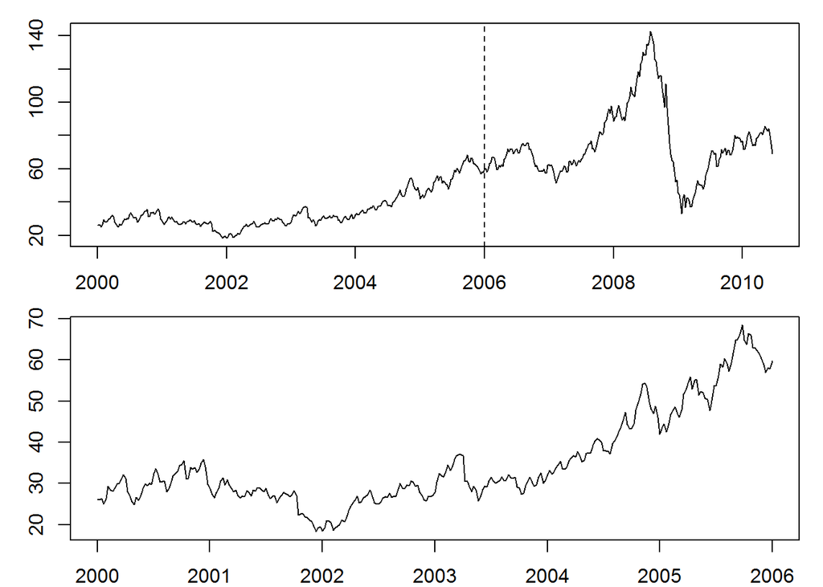

```r
par(mfrow=2:1, mar=c(2,3,1,1))
data(oil)
plot(oil)
abline(v=2006, lty=2)
oil2006 <- window(oil, end = 2006)
plot(oil2006)
```

The P/ACF of the detrended oil price appears to tail off, suggesting an ARIMA(1,1,1)

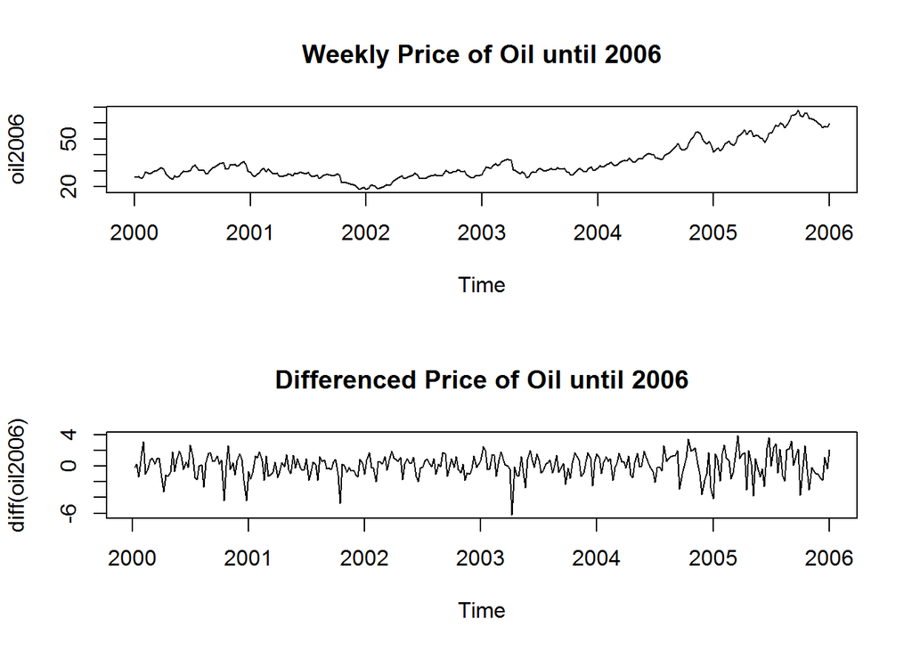

```r
par(mfrow=2:1)
plot(oil2006, main="Weekly Price of Oil until 2006")
plot(diff(oil2006), main="Differenced Price of Oil until 2006")
```

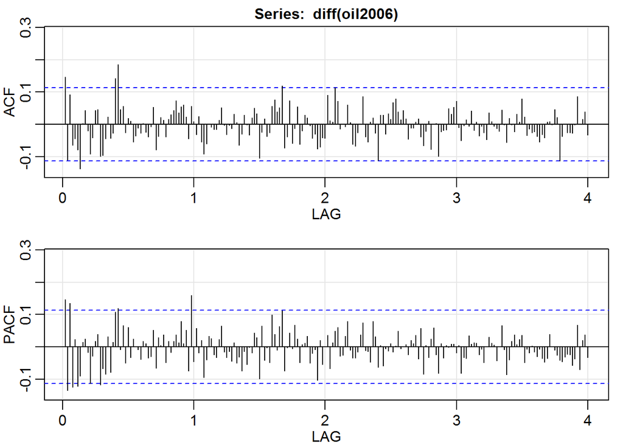

```r
invisible(acf2(diff(oil2006)))
```

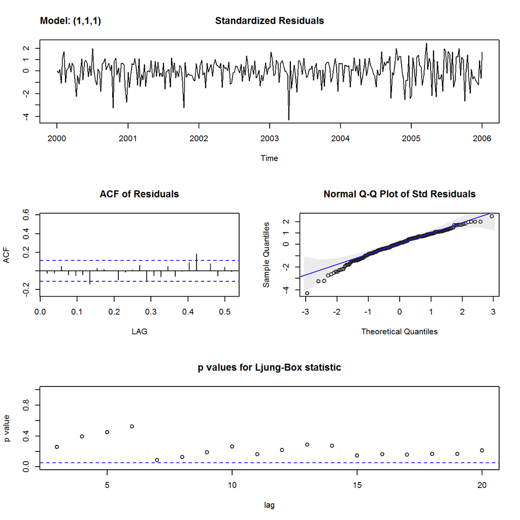

```
$ttable
         Estimate     SE t.value p.value
ar1       -0.4987 0.0995 -5.0131  0.0000
ma1        0.7316 0.0734  9.9732  0.0000
constant   0.1091 0.0936  1.1664  0.2443
```

```r
sarima(oil2006, p = 1, d = 1, q = 1)["ttable"]
```

The parameter estimates $\phi$ and $\theta$ are all significant but the constant drift $\mu$.

The residual analysis looks fine too.

** Overfit: ARIMA(2, 1, 1) and ARIMA(1, 1, 2)**

We can try to add and AR parameter and an MA parameters to see it they make a difference.

```r
oil_fit1 <- sarima(oil2006, p = 2, d = 1, q = 1, details=FALSE)
oil_fit1$ttable
```

```
         Estimate     SE t.value p.value
ar1       -0.4704 0.1117 -4.2121  0.0000
ar2       -0.0738 0.0652 -1.1319  0.2586
ma1        0.6771 0.0986  6.8696  0.0000
constant   0.1088 0.0878  1.2391  0.2163
```

```r
oil_fit2 <- sarima(oil2006, p = 1, d = 1, q = 2, details=FALSE)
oil_fit2$ttable
```

```
         Estimate     SE t.value p.value
ar1       -0.3664 0.1816 -2.0178  0.0445
ma1        0.5777 0.1818  3.1777  0.0016
ma2       -0.0836 0.0837 -0.9989  0.3186
constant   0.1088 0.0884  1.2306  0.2194
```

## 14.2 Diagnostics - Simulated Overfitting

One way to check an analysis is to overfit the model by adding an extra parameter to see if it makes a difference in the results. If adding parameters changes the results drastically, then you should rethink your model. If, however, the results do not change by much, you can be confident that your fit is correct.

Simulated 250 observations from an ARIMA(0,1,1) model with MA parameter .9

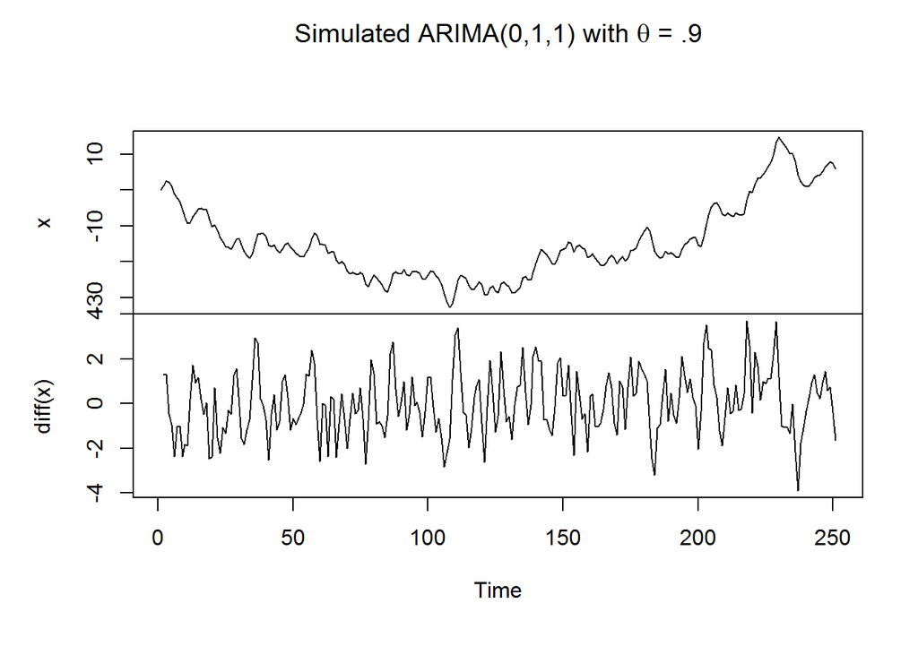

```r
x <- arima.sim(model=list(order=c(0,1,1), ma=.9), n=250)
plot(cbind(x, diff(x)), main=expression(paste("Simulated ARIMA(0,1,1) with ",theta," = .9")))
```

Plot sample P/ACF pair of the differenced data shows ACF cuts off lag 1 and PCF tails off, confirming an MA model.

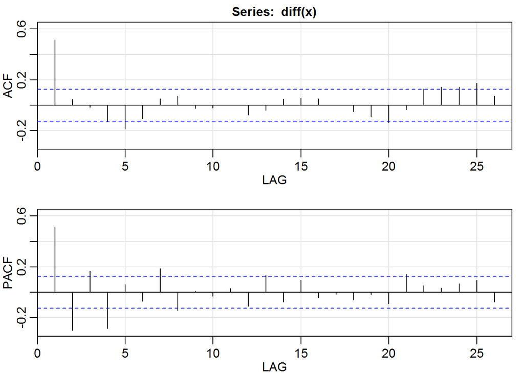

```r
invisible(acf2(diff(x)))
```

Fit the first model, compare parameters, check diagnostics

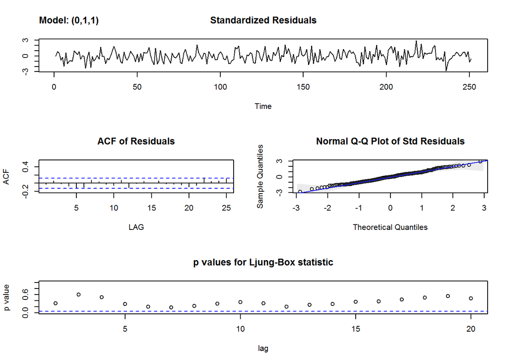

```
$fit

Call:
stats::arima(x = xdata, order = c(p, d, q), seasonal = list(order = c(P, D,
    Q), period = S), xreg = constant, optim.control = list(trace = trc, REPORT = 1,
    reltol = tol))

Coefficients:
         ma1  constant
      0.9102    0.0208
s.e.  0.0269    0.1272

sigma^2 estimated as 1.113:  log likelihood = -369.05,  aic = 744.1

$degrees_of_freedom
[1] 248

$ttable
         Estimate     SE t.value p.value
ma1        0.9102 0.0269 33.8015    0.00
constant   0.0208 0.1272  0.1639    0.87

$AIC
[1] 1.123417

$AICc
[1] 1.131772

$BIC
[1] 0.1515085
```

```r
sarima(x, 0,1,1)
```

The ARIMA(0,1,1) easily identified with good parameter estimates.

Fit the second model adding a parameter: ARIMA(0,1,2)

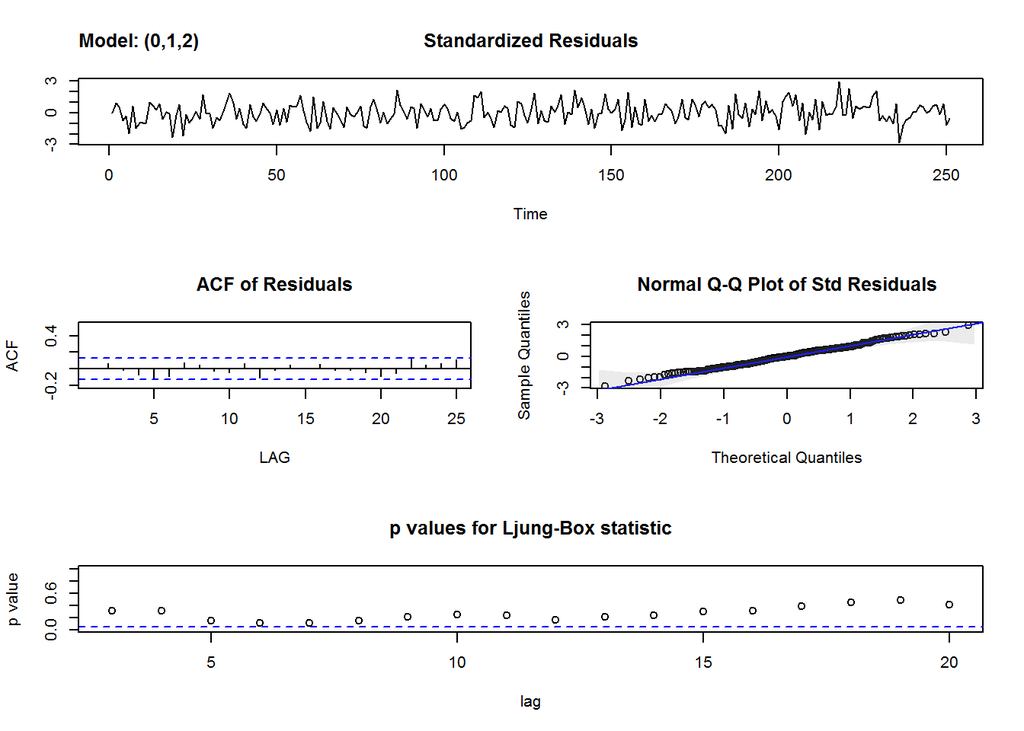

```
$fit

Call:
stats::arima(x = xdata, order = c(p, d, q), seasonal = list(order = c(P, D,
    Q), period = S), xreg = constant, optim.control = list(trace = trc, REPORT = 1,
    reltol = tol))

Coefficients:
         ma1      ma2  constant
      0.8912  -0.0208    0.0210
s.e.  0.0598   0.0588    0.1246

sigma^2 estimated as 1.113:  log likelihood = -368.99,  aic = 745.98

$degrees_of_freedom
[1] 247

$ttable
         Estimate     SE t.value p.value
ma1        0.8912 0.0598 14.8968  0.0000
ma2       -0.0208 0.0588 -0.3543  0.7234
constant   0.0210 0.1246  0.1689  0.8660

$AIC
[1] 1.130884

$AICc
[1] 1.1395

$BIC
[1] 0.1730209
```

```r
sarima(x,0,1,2)
```

As you can see from the t-table, the second MA parameter is not significantly different from zero and the first MA parameter is approximately the same in each run. Also, the AIC and BIC both increase when the parameter is added. In addition, the residual analysis of your ARIMA(0,1,1) model is fine. All of these facts together indicate that you have a successful model fit.

## 14.3 Diagnostics - Global Temperatures

```r
plot(cbind(globtemp, diff(globtemp)), main="Global mean land-ocean temperature deviations")
```

[output not shown]

Fit ARIMA(0,1,2) to globtemp and check diagnostics

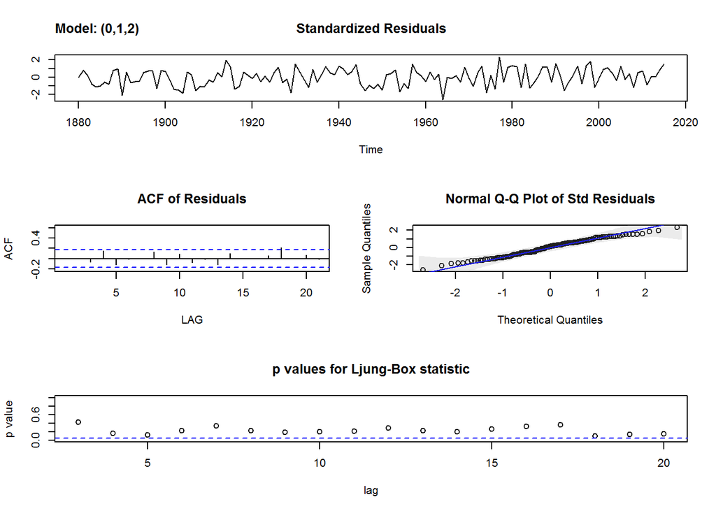

```
$fit

Call:
stats::arima(x = xdata, order = c(p, d, q), seasonal = list(order = c(P, D,
    Q), period = S), xreg = constant, optim.control = list(trace = trc, REPORT = 1,
    reltol = tol))

Coefficients:
          ma1      ma2  constant
      -0.3984  -0.2173    0.0072
s.e.   0.0808   0.0768    0.0033

sigma^2 estimated as 0.00982:  log likelihood = 120.32,  aic = -232.64

$degrees_of_freedom
[1] 132

$ttable
         Estimate     SE t.value p.value
ma1       -0.3984 0.0808 -4.9313  0.0000
ma2       -0.2173 0.0768 -2.8303  0.0054
constant   0.0072 0.0033  2.1463  0.0337

$AIC
[1] -3.579224

$AICc
[1] -3.562273

$BIC
[1] -4.514974
```

```r
sarima(globtemp, 0,1,2)
```

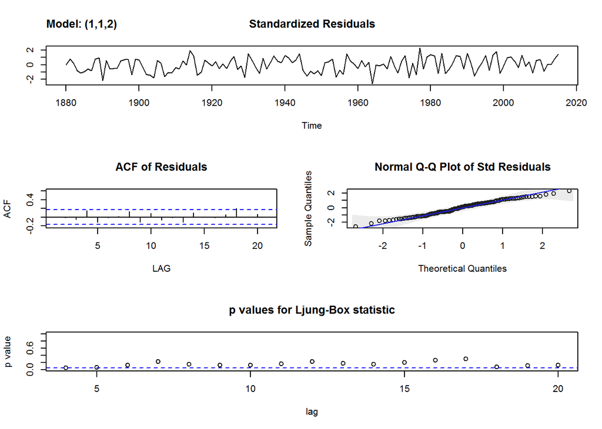

```
$fit

Call:
stats::arima(x = xdata, order = c(p, d, q), seasonal = list(order = c(P, D,
    Q), period = S), xreg = constant, optim.control = list(trace = trc, REPORT = 1,
    reltol = tol))

Coefficients:
         ar1      ma1      ma2  constant
      0.1035  -0.4911  -0.1741    0.0072
s.e.  0.2732   0.2617   0.1453    0.0032

sigma^2 estimated as 0.009809:  log likelihood = 120.39,  aic = -230.78

$degrees_of_freedom
[1] 131

$ttable
         Estimate     SE t.value p.value
ar1        0.1035 0.2732  0.3787  0.7055
ma1       -0.4911 0.2617 -1.8762  0.0629
ma2       -0.1741 0.1453 -1.1979  0.2331
constant   0.0072 0.0032  2.2108  0.0288

$AIC
[1] -3.565603

$AICc
[1] -3.547503

$BIC
[1] -4.479936
```

```r
sarima(globtemp, 1,1,2)
```

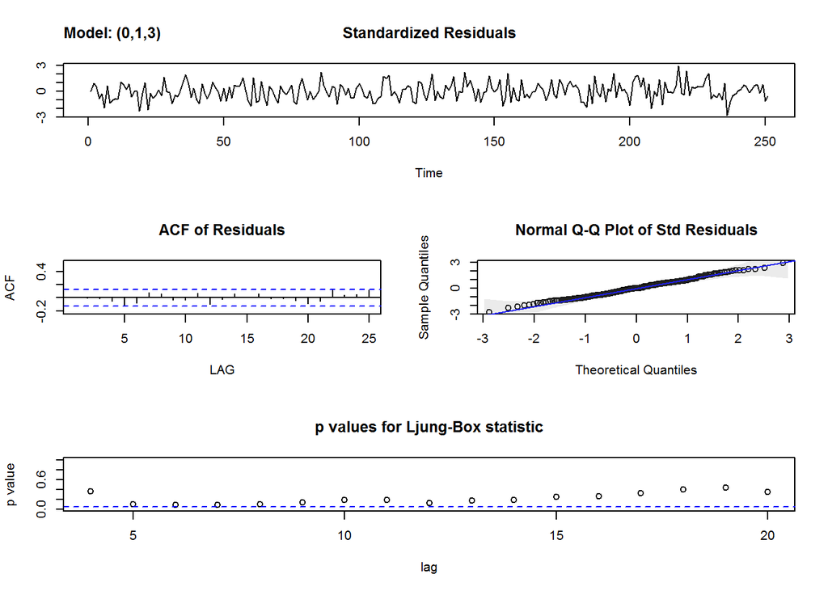

[output not shown]

```r
sarima(x, 0,1,3)
```

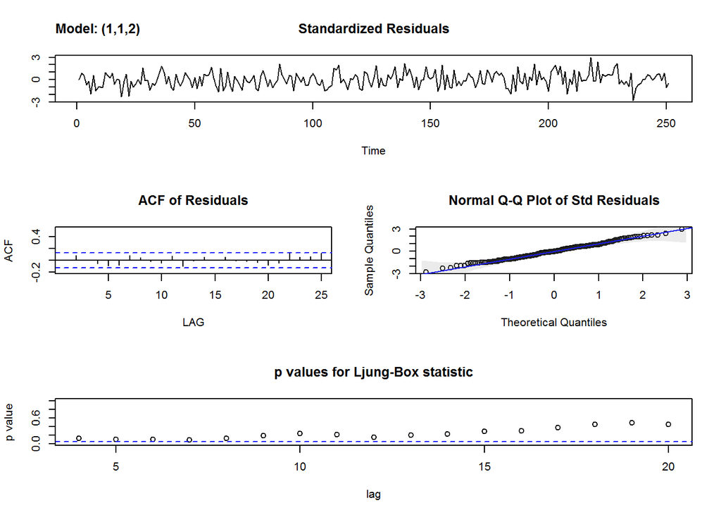

[output not shown]

```r
sarima(x, 1,1,2)
```

# 15 Forecasting ARIMA

## 15.1 Forecasting ARIMA Processes

- The model describes how the dynamics of the time series behave over time
- Forecasting simply continues the model dynamics into the future
- Use sarima.for() to forecast in the astsa-package. It’s similar to samira() but specifies the forescasting horizon

Forecast 52 weeks from 2006 on shown in red. The dark grey area denotes +/- 1 Root Mean Squared prediction Error (RMSE) bounds and the light grey ribbon denotes +/- 2 RMSE bounds which represents 95% prediction interval.

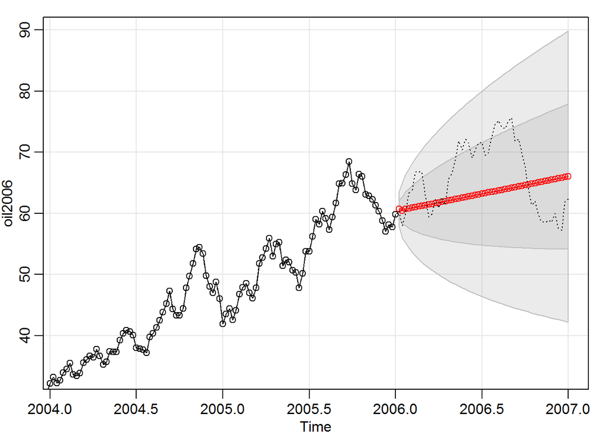

```r
data(oil)
oil2006 <- window(oil, end = 2006)
oil2007 <- window(oil, end = 2007)
invisible(sarima.for(oil2006, n.ahead = 52, 1, 1, 1))
lines(oil2007, lty=3)
```

## 15.2 Forecasting Simulated ARIMA

Simulated 120 observations from an ARIMA(1,1,0) model with AR parameter .9.

```r
y <- arima.sim(model=list(order=c(1,1,0), ar=.9), n=120)
```

Taking the first 100 observations for model fitting.

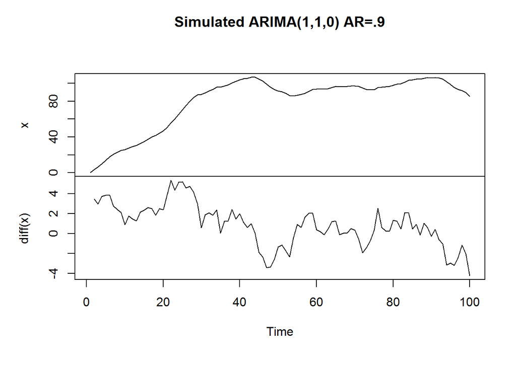

```r
x <- window(y, end=100)
plot(cbind(x, diff(x)), main="Simulated ARIMA(1,1,0) AR=.9")
```

Plot P/ACF pair of differenced data show ACF tails off and PACF cuts off lag 1 confirming AR(1)

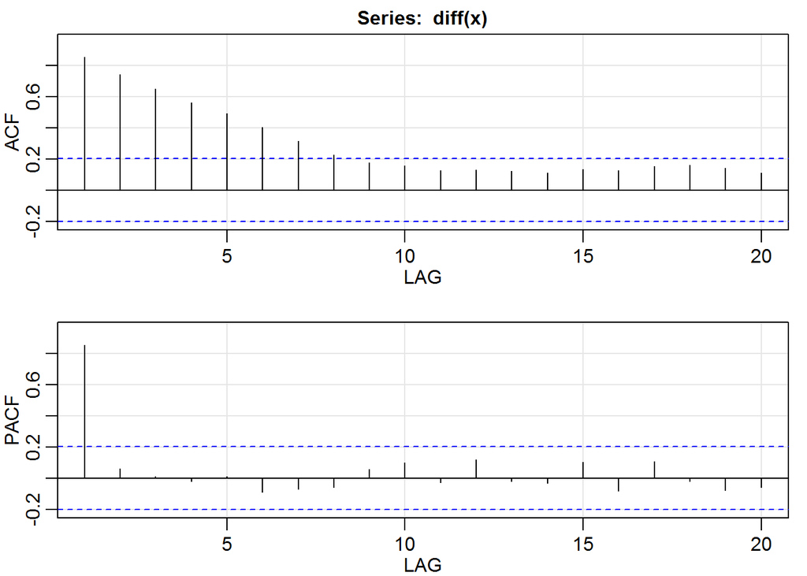

```r
invisible(acf2(diff(x)))
```

Fitting the AR(1,1,0) model and checking t-table and diagnostics confirm parameters estimate.

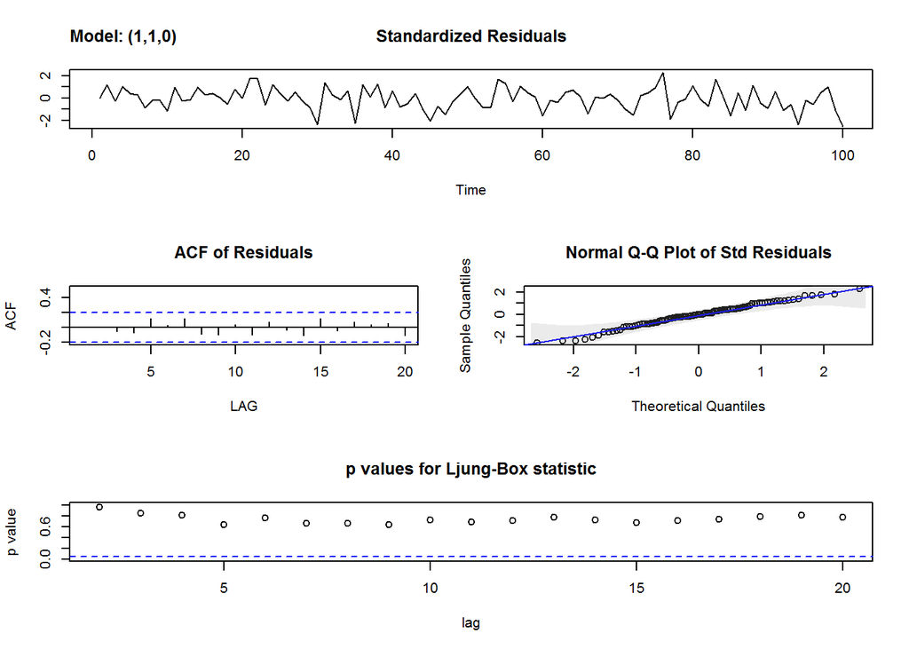

```
$fit

Call:
stats::arima(x = xdata, order = c(p, d, q), seasonal = list(order = c(P, D,
    Q), period = S), xreg = constant, optim.control = list(trace = trc, REPORT = 1,
    reltol = tol))

Coefficients:
        ar1  constant
      0.911    0.6477
s.e.  0.045    0.9923

sigma^2 estimated as 0.9218:  log likelihood = -137.33,  aic = 280.66

$degrees_of_freedom
[1] 97

$ttable
         Estimate     SE t.value p.value
ar1        0.9110 0.0450 20.2663  0.0000
constant   0.6477 0.9923  0.6527  0.5155

$AIC
[1] 0.958526

$AICc
[1] 0.981026

$BIC
[1] 0.01062938
```

```r
sarima(x, 1,1,0)
```

Forecast the data 20 time periods ahead

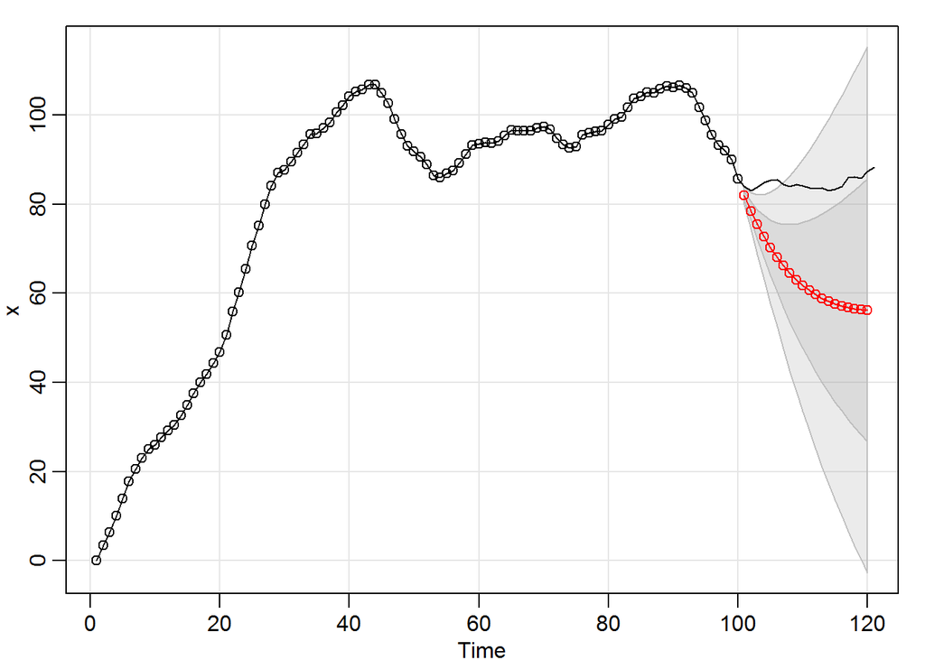

```r
invisible(sarima.for(x, n.ahead = 20, p = 1, d = 1, q = 0) )
lines(y)
```

## 15.3 Forecasting Global Temperatures

Forecasting the annual global temperature deviations globtemp to 2050.

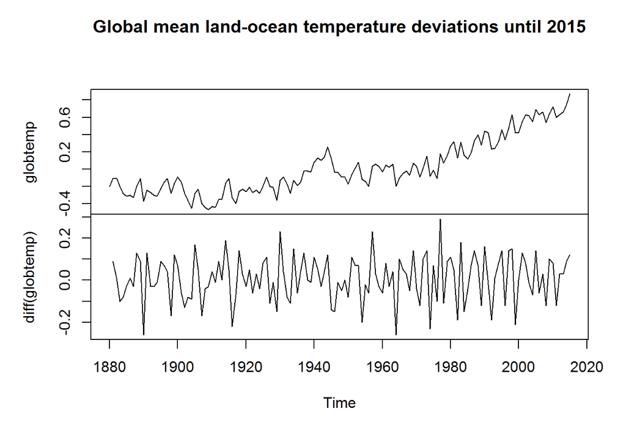

```r
data(globtemp)
plot(cbind(globtemp, diff(globtemp)), main="Global mean land-ocean temperature deviations until 2015")
```

As checked before, ARIMA(0,1,2) is the best fit for this data. It can be re-checked by fitting an ARIMA(0,1,2) to globtemp.

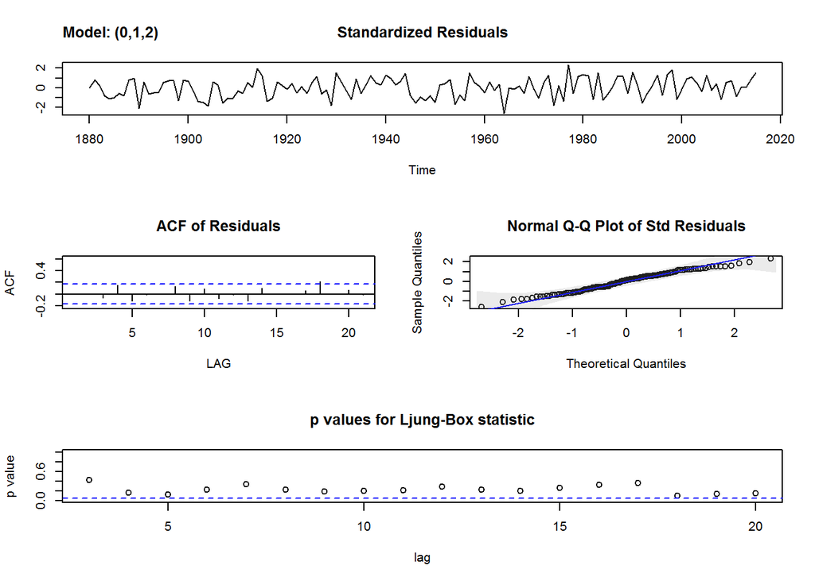

```
$fit

Call:
stats::arima(x = xdata, order = c(p, d, q), seasonal = list(order = c(P, D,
    Q), period = S), xreg = constant, optim.control = list(trace = trc, REPORT = 1,
    reltol = tol))

Coefficients:
          ma1      ma2  constant
      -0.3984  -0.2173    0.0072
s.e.   0.0808   0.0768    0.0033

sigma^2 estimated as 0.00982:  log likelihood = 120.32,  aic = -232.64

$degrees_of_freedom
[1] 132

$ttable
         Estimate     SE t.value p.value
ma1       -0.3984 0.0808 -4.9313  0.0000
ma2       -0.2173 0.0768 -2.8303  0.0054
constant   0.0072 0.0033  2.1463  0.0337

$AIC
[1] -3.579224

$AICc
[1] -3.562273

$BIC
[1] -4.514974
```

```r
sarima(globtemp, 0,1,2)
```

Forecasting data 35 years into the future

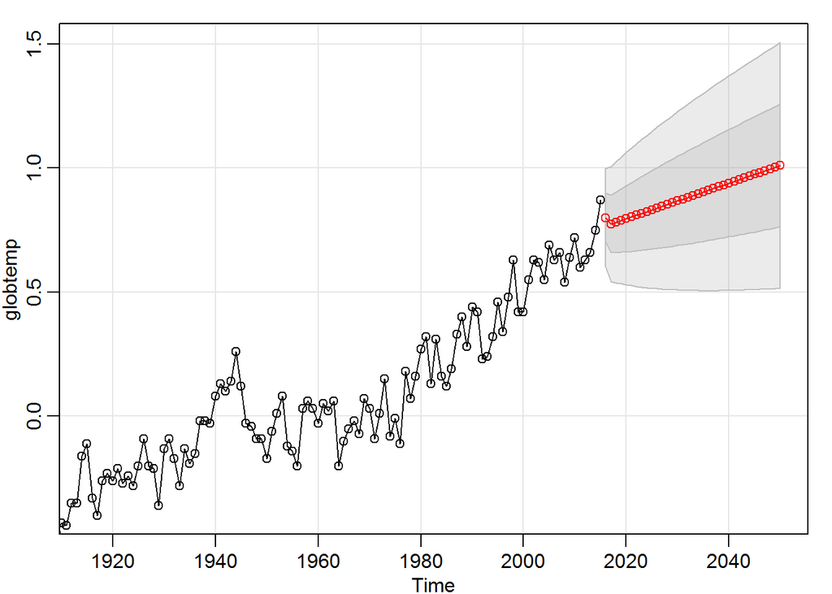

```
$pred
Time Series:
Start = 2016
End = 2050
Frequency = 1
 [1] 0.7995567 0.7745381 0.7816919 0.7888457 0.7959996 0.8031534 0.8103072 0.8174611 0.8246149
[10] 0.8317688 0.8389226 0.8460764 0.8532303 0.8603841 0.8675379 0.8746918 0.8818456 0.8889995
[19] 0.8961533 0.9033071 0.9104610 0.9176148 0.9247687 0.9319225 0.9390763 0.9462302 0.9533840
[28] 0.9605378 0.9676917 0.9748455 0.9819994 0.9891532 0.9963070 1.0034609 1.0106147

$se
Time Series:
Start = 2016
End = 2050
Frequency = 1
 [1] 0.09909556 0.11564576 0.12175580 0.12757353 0.13313729 0.13847769 0.14361964 0.14858376
 [9] 0.15338730 0.15804492 0.16256915 0.16697084 0.17125943 0.17544322 0.17952954 0.18352490
[17] 0.18743511 0.19126540 0.19502047 0.19870459 0.20232164 0.20587515 0.20936836 0.21280424
[25] 0.21618551 0.21951471 0.22279416 0.22602604 0.22921235 0.23235497 0.23545565 0.23851603
[33] 0.24153763 0.24452190 0.24747019
```

```r
sarima.for(globtemp, 35, 0,1,2)
```

# 16 Seasonal ARIMA

## 16.1 Pure Seasonal Models

- Often collect data with a known seasonal component
- The letter S denotes de seasonal period
- Monthly Airline Passenger Numbers 1949-1960 (1 cycle every S = 12 months)
- Johnson and Johnson Quarterly Earnings Per Share 1960-1980 (1 cycle every S = 4 quarters)

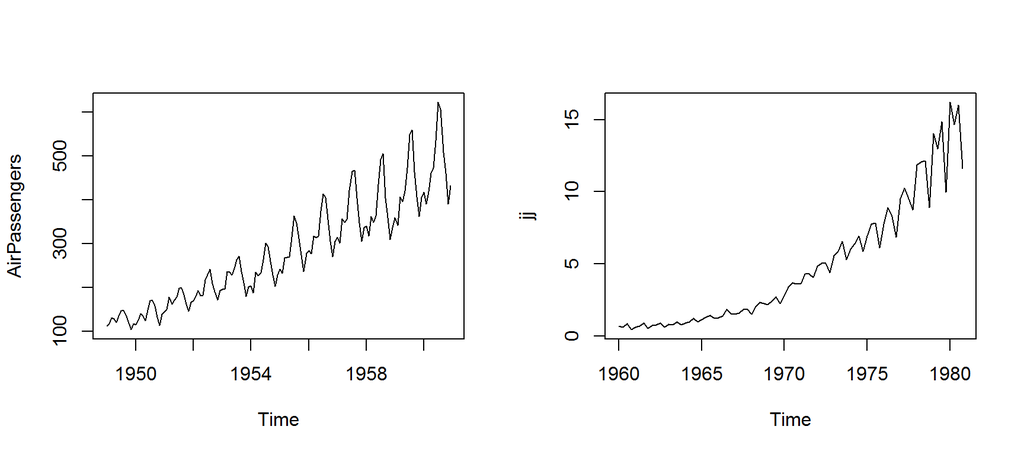

```r
par(mfrow=1:2)
plot(AirPassengers)
plot(jj)
```

Although not realist it’s instructive to first consider pure seasonal models such as an $SAR(P=1)_{S=12}$

$$X_t = \phi X_{t-12} + W_t$$
The model which wight be appropriate for average monthly temperatures states that what happens this month depends on what happened in the same month last year plus a little bit of noise. January is tipically small while June-July are tipically large.

### 16.1.1 ACF and PACF for Pure Seasonal Models

The behavior of the P/ACF for seasonal models is similar to non-seasonal models, but things happend only at the seasons 1S, 2S, 3S…

| function | $SAR(P)_s$ | $SMA(Q)_s$ | $SARMA(P, Q)_s$ |
| --- | --- | --- | --- |
| ACF* | Tails off | Cut off lag QS | Tails off |
| PACF* | Cuts off lag PS | Tails off | Tails off |

- the values at non-seasonal lags are zero

### 16.1.2 Fit a Pure Seasonal Model

Simulating 250 observations from a pure seasonal model given by
$$X_t=.9X_{t−12}+W_t+.5W_{t−12}$$
,

which we would denote as a SARMA(P = 1, Q = 1)$_{S = 12}$.

Three years of data and the model ACF and PACF are plotted.

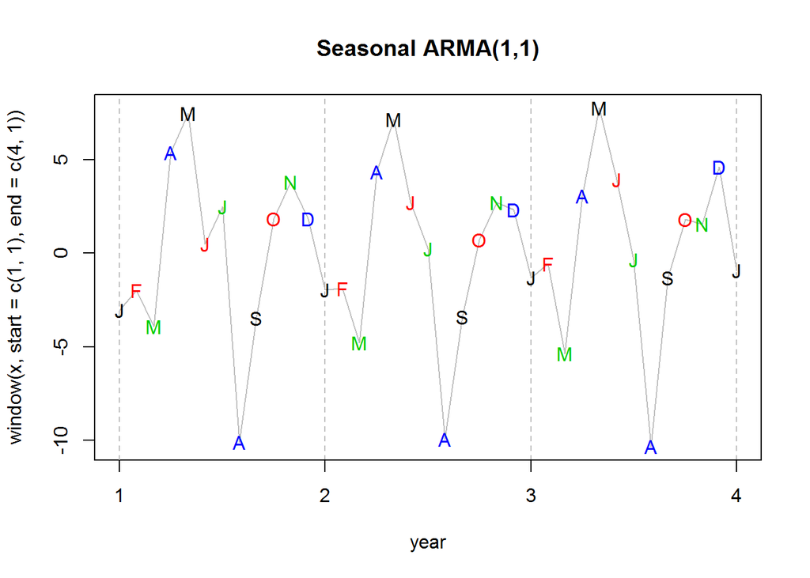

```r
Months <- c("J", "F", "M", "A", "M", "J", "J", "A", "S", "O", "N", "D")
plot(window(x, start=c(1,1), end=c(4,1)), type="l", col="gray", xaxt="n", xlab="year", main="Seasonal ARMA(1,1)")
abline(v=1:4, lty=2, col="gray")
points(window(x, start=c(1,1), end=c(4,1)), pch=Months, col=1:4)
axis(1, 1:4)
```

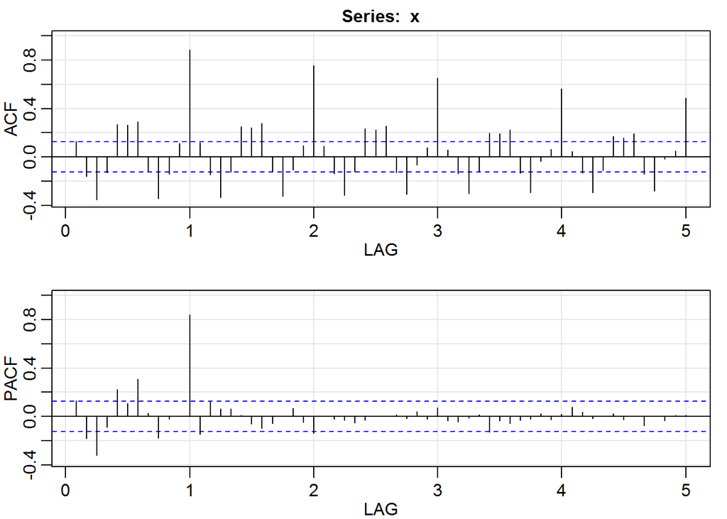

```r
invisible(acf2(x, max.lag = 60))
```

Fit the seasonal model to x

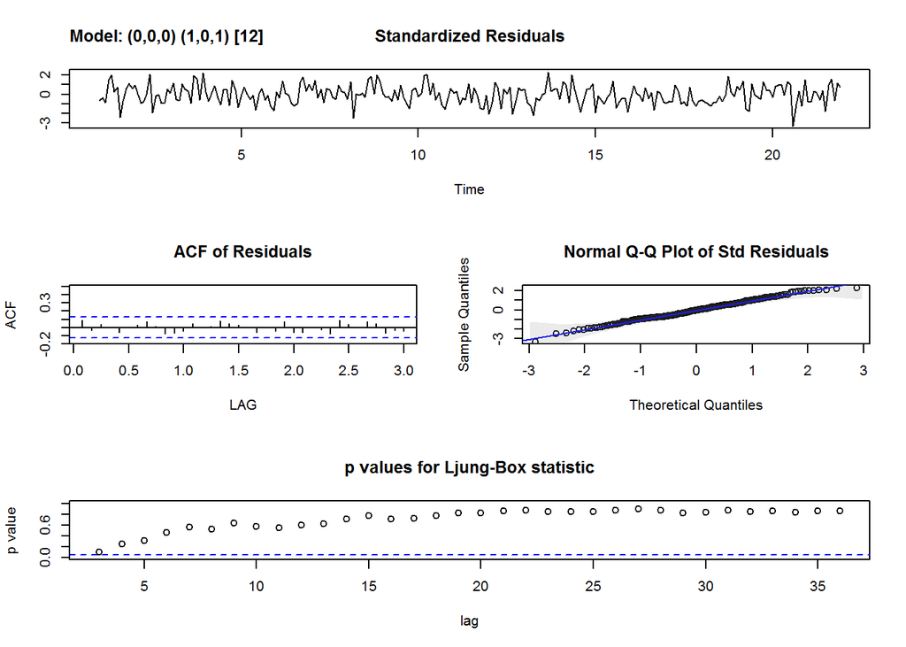

```
$fit

Call:
stats::arima(x = xdata, order = c(p, d, q), seasonal = list(order = c(P, D,
    Q), period = S), xreg = xmean, include.mean = FALSE, optim.control = list(trace = trc,
    REPORT = 1, reltol = tol))

Coefficients:
        sar1    sma1    xmean
      0.9311  0.4824  -0.5766
s.e.  0.0204  0.0633   0.8797

sigma^2 estimated as 0.9767:  log likelihood = -372.74,  aic = 753.48

$degrees_of_freedom
[1] 249

$ttable
      Estimate     SE t.value p.value
sar1    0.9311 0.0204 45.6189  0.0000
sma1    0.4824 0.0633  7.6158  0.0000
xmean  -0.5766 0.8797 -0.6554  0.5128

$AIC
[1] 1.000217

$AICc
[1] 1.008796

$BIC
[1] 0.04223375
```

```r
sarima(x, p = 0, d = 0, q = 0, P = 1, D = 0, Q = 1, S = 12)
```

Fitting a seasonal model using sarima() requires a few additional arguments, but follows the same basic process as nonseasonal models.